# Visualizing Alignments in IGV

Yujin Choi

2023-03-14

# Visualizing and Interpreting Alignments

Used the reference genome `GRCh38.p13 (hg38)` and gene annotation (version 109) from ENSEMBL. The ACTB gene was located at `chr7:5,525,148-5,532,601`. I also chose the following (single-end) samples: `SRR7093809` (young), `SRR7093851` (old), and `SRR7093942` (hgps).

```r
samtools view -b ../alignments/SRR7093809.Aligned.sortedByCoord.out.bam 7:5525148-5532601 > SRR7093809.actb.bam
samtools index SRR7093809.actb.bam

samtools view -b ../alignments/SRR7093851.Aligned.sortedByCoord.out.bam 7:5525148-5532601 > SRR7093851.actb.bam
samtools index SRR7093851.actb.bam

samtools view -b ../alignments/SRR7093942.Aligned.sortedByCoord.out.bam 7:5525148-5532601 > SRR7093942.actb.bam
samtools index SRR7093942.actb.bam

cat /athena/angsd/scratch/yuc4017/genome/Homo_sapiens.GRCh38.109.gtf | sort -S4G -k1,1 -k4,4n | bgzip -c > Homo_sapiens.GRCh38.109.sorted.gtf.gz
tabix Homo_sapiens.GRCh38.109.sorted.gtf.gz
```

```r
scp -r yuc4017@aphrodite.med.cornell.edu:/athena/angsd/scratch/yuc4017/IGV/ .
```

Loaded in the BAM files onto IGV. Some observations from looking at the alignments:

1. The samples are clearly stranded as we see that all of the fragments that aligned to ACTB are in one orientation, instead of seeing a mix of forward and reverse strands.
2. Interestingly enough, the SRR7093851 sample which represents the old population has a very different coverage peak pattern compared to both the young and HGPS. It is missing half the coverage you would see in the other two samples. According to literature, aging disrupts the dynamics of the actin cytoskeleton and alters alters the expression of actin. [[1]](https://pubmed.ncbi.nlm.nih.gov/36139471/)
3. At around 5,527,640bp there seems to be a lot of variance between A’s and C’s with a slight preference for C’s (which match the reference genome).

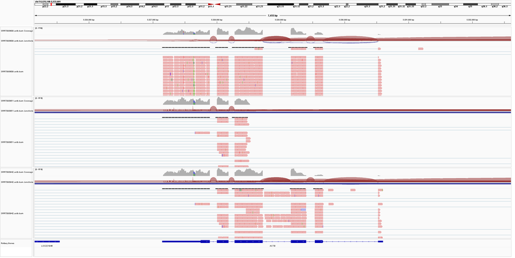

*Fig. 1. IGV Snapshot of SRR7093809, SRR7093851, SRR7093942 Alignment to ACTB Gene*

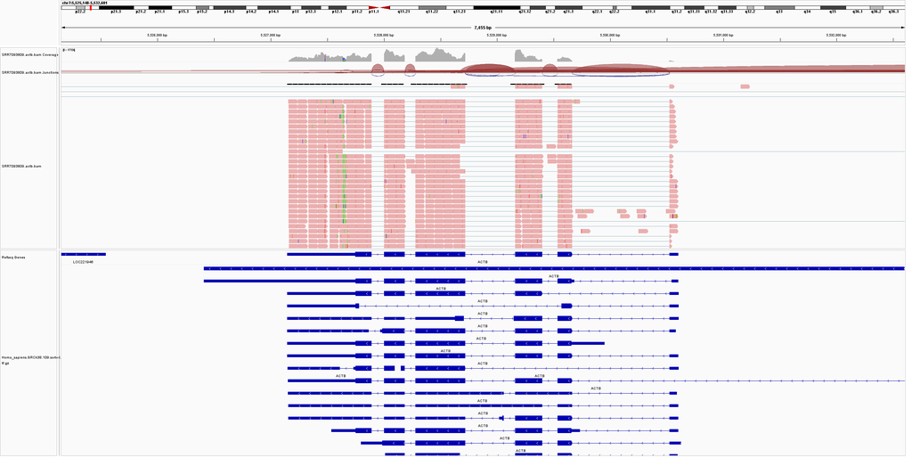

*Fig. 2. IGV Snapshot of SRR7093809 with ENSEMBL Gene Annotation File*